# STA365_homework2_code

Ruike Xu

3/29/2022

## Question 2

```r
# install.packages("rjags")
# install.packages("coda")

set.seed(1006562550)
library(coda)
library(R2jags)
library(lattice)
```

$$Warren:\ \ \tau(1-\theta)+\theta(1-\lambda)$$
$$Trump(\psi):\ \ \lambda\theta + (1-\tau)(1-\theta)$$

```r
# Model construction with likelihood function and prior
model.JAGS = function(){
    y ~ dbinom(psi, n)
    theta ~ dbeta(3, 7)
    tau ~ dbeta(6, 4)
    lambda ~ dbeta(7, 3)
    psi <- theta * lambda + (1 - theta) * (1 - tau)
  }
```

The model we are constructing is intended to predict which candidate is likely to win the 2024 US presidential election (Donald Trump or Elizabeth Warren), which is based on binomial likelihood and beta prior. $\theta$ is the probability that the voter claims to vote for trump (might lying), thus, $1 - \theta$ is the probability that the person claims to vote for Warren. $\lambda$ is the percentage of the population that is actually willing to vote for Trump while $\tau$ is the percentage of the population that is actually willing to vote for Warren. We can detect the ‘Quasi Liberal’ and ‘Quasi Republican’ as $1-\lambda$ and $1-\tau$. To be more specific, the percentage of the population that claimed they would vote for Trump/Warren but ended voting the opposite.

Therefore, we can derive that the actual probability of a person voting for Trump as $\psi:\lambda\theta + (1-\tau)(1-\theta)$ and the actual probability of a person voting for Warren as $\tau(1-\theta)+\theta(1-\lambda)$

To define $\tau$ and $\lambda$, we would assume more Republican people are less willing to claim their feelings in Liberal states, so $\tau$ ~ Beta(6, 4) and $\lambda$ ~ Beta(7,3)

```r
# Simulating data
n = 100000
y = 30000
data.JAGS = list(y = y, n = n)
```

```r
# Randomly select the initial values
inits.JAGS = function(){
  return(list(theta=rbeta(1, 3, 7),tau=rbeta(1, 6, 4),lambda=rbeta(1, 7, 3)))
}
```

```r
# Select parameters that will be simulated with MCMC model
para.JAGS = c("theta", "tau", "lambda", "psi")
```

```r
# Fit the MCMC model, number of iterations = 90000, burn in = 10000
fit.JAGS = jags(data=data.JAGS,inits=inits.JAGS,
                parameters.to.save = para.JAGS,
                n.chains=1,
                n.iter=90000,
                n.burnin=10000,
                model.file=model.JAGS)
```

```
## module glm loaded
```

```r
# Print model fit summary
print(fit.JAGS)
```

```
## Inference for Bugs model at "C:/Users/Ruike Xu/AppData/Local/Temp/Rtmpgtofxy/model862071d15d2a.txt", fit using jags,
##  1 chains, each with 90000 iterations (first 10000 discarded), n.thin = 80
##  n.sims = 1000 iterations saved
##          mu.vect sd.vect   2.5%    25%    50%    75%  97.5%
## lambda     0.620   0.148  0.348  0.507  0.625  0.732  0.880
## psi        0.300   0.001  0.297  0.299  0.300  0.301  0.303
## tau        0.791   0.050  0.713  0.752  0.784  0.830  0.891
## theta      0.236   0.110  0.067  0.152  0.226  0.308  0.478
## deviance  12.724   1.272 11.791 11.890 12.245 13.030 16.160
##
## DIC info (using the rule, pD = var(deviance)/2)
## pD = 0.8 and DIC = 13.5
## DIC is an estimate of expected predictive error (lower deviance is better).
```

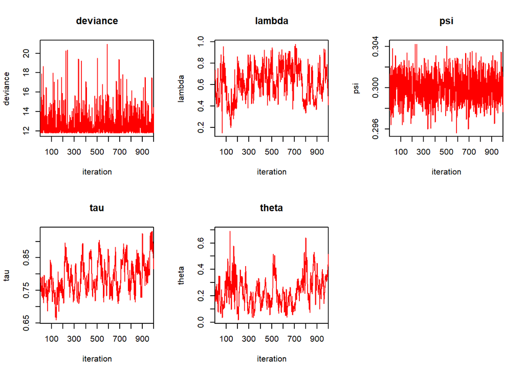

```r
# Generate traceplots
traceplot(fit.JAGS,mfrow=c(2,3),ask=FALSE)
```

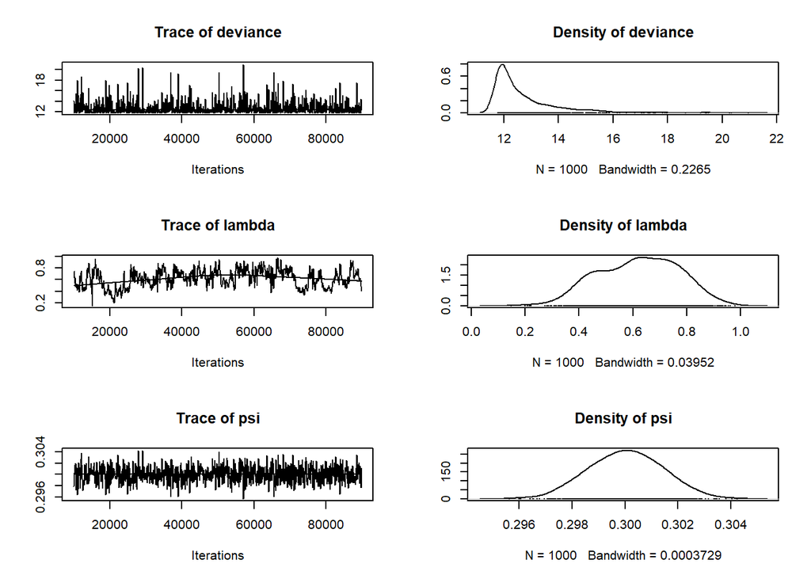

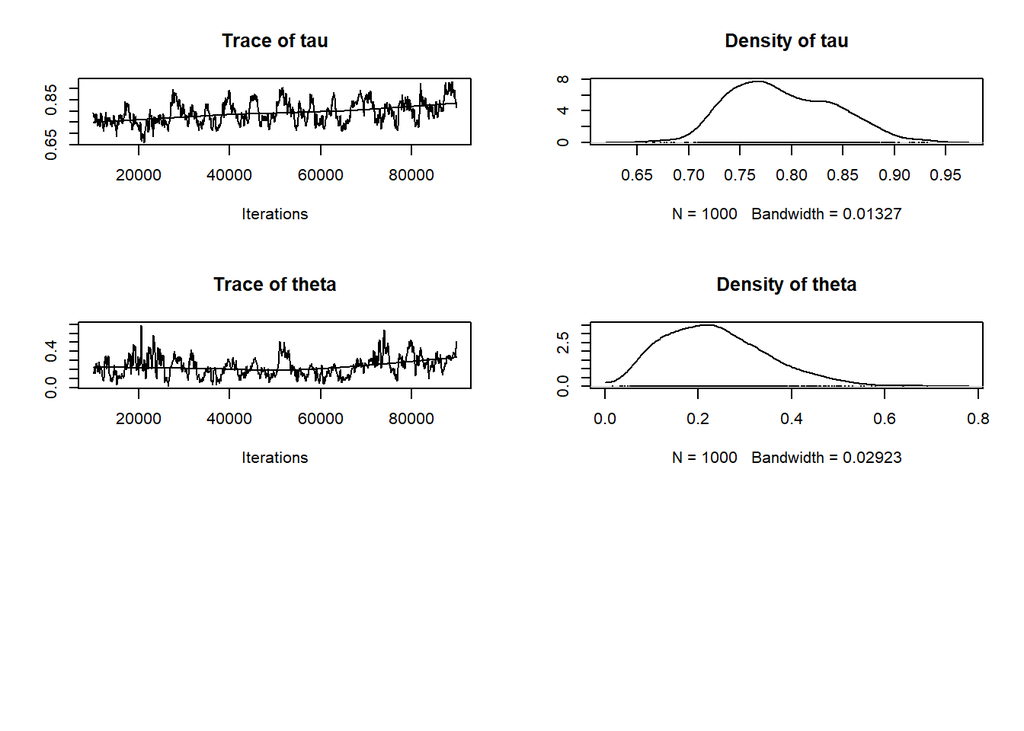

```r
# Plot MCMC object to show all parameter densities along with traceplots
fit.JAGS.mcmc = as.mcmc(fit.JAGS)
plot(fit.JAGS.mcmc,ask=FALSE)
```

```r
# Summary as a MCMC object
summary(fit.JAGS.mcmc)
```

```
##
## Iterations = 10001:89921
## Thinning interval = 80
## Number of chains = 1
## Sample size per chain = 1000
##
## 1. Empirical mean and standard deviation for each variable,
##    plus standard error of the mean:
##
##             Mean      SD  Naive SE Time-series SE
## deviance 12.7236 1.27180 4.022e-02      4.022e-02
## lambda    0.6201 0.14844 4.694e-03      2.407e-02
## psi       0.3000 0.00140 4.429e-05      4.429e-05
## tau       0.7912 0.04983 1.576e-03      8.174e-03
## theta     0.2364 0.10978 3.472e-03      1.788e-02
##
## 2. Quantiles for each variable:
##
##              2.5%     25%     50%     75%   97.5%
## deviance 11.79091 11.8904 12.2452 13.0302 16.1600
## lambda    0.34765  0.5065  0.6245  0.7321  0.8804
## psi       0.29735  0.2990  0.3000  0.3010  0.3027
## tau       0.71344  0.7523  0.7839  0.8302  0.8906
## theta     0.06721  0.1524  0.2263  0.3076  0.4782
```

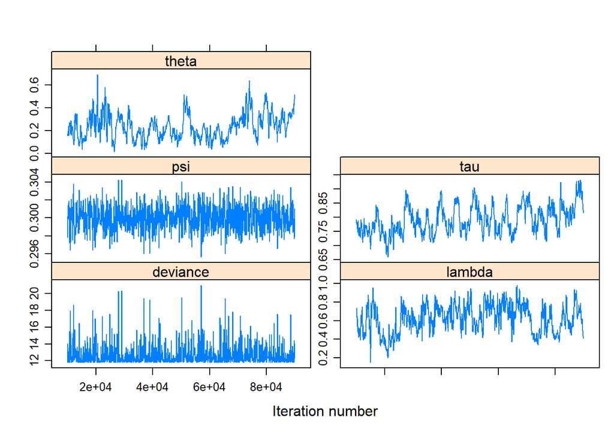

```r
# Traceplots as a MCMC object
xyplot(fit.JAGS.mcmc,layout=c(2,3))
```

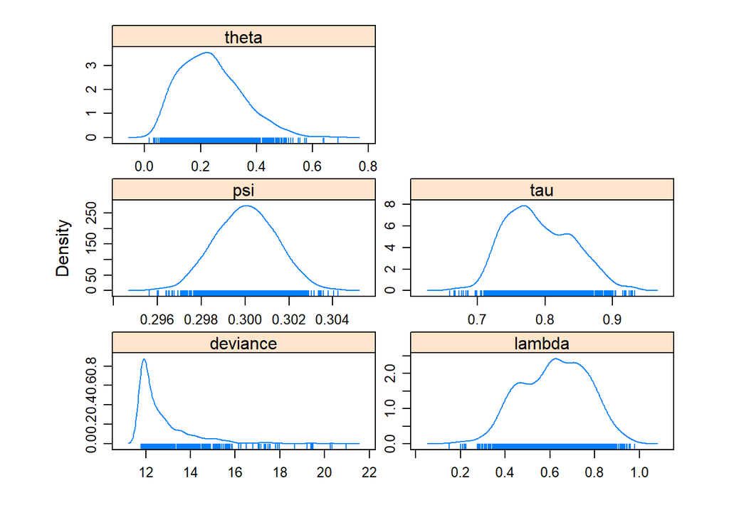

```r
# Density plot as a MCMC object
densityplot(fit.JAGS.mcmc)
```

## Question 3

### Part(a)

$$\begin{aligned}
\theta_1 = 1 + 0.065X_1
= 1 + 0.065 * 95 = 7.175 \\
H_1 \sim Poisson(7.175) \\
\end{aligned}$$

```r
# Probability of Poisson distribution for at least 2 infections
P_atleast2 <- 1 - ppois(1, 7.175)
P_atleast2
```

```
## [1] 0.9937422
```

Therefore, the probability that Indonesia observes at least 2 infections in the given time period is 0.994

### Part(b)

$$\begin{aligned}
\theta_2 = 1 + 0.065X_2
= 1 + 0.065 * 150 = 10.75 \\
H_2 \sim Poisson(10.75) \\
\end{aligned}$$

```r
# Probability of Poisson distribution for at least 28 infections
P_atleast28 <- 1 - ppois(27, 10.75)
P_atleast28
```

```
## [1] 8.378949e-06
```

Therefore, the probability that Singapore observes 28 or more infections in the given time period is approximately 0.